# Reproducible Research: Peer Assessment 2

Victor Bernal

11 november, 2019

# Synopsis

Severe weather events can cause public health (e.g. fatalities, injuries) and economic problems (e.g. property and crops damage). Thus the interest to identify the events with the largest human and economic impact. This Report uses the Storm Database of the U.S. National Oceanic and Atmospheric Administration (NOAA) The events in the database start in the year 1950 and end in November 2011. For more details https://www.coursera.org/learn/reproducible-research/peer/OMZ37/course-project-2.

# Loading and preprocessing the data

```r
fileurl <- 'https://d396qusza40orc.cloudfront.net/repdata%2Fdata%2FStormData.csv.bz2'

if(!file.exists('repdata_data_StormData.csv.bz2')) {
  download.file(fileurl, 'repdata_data_StormData.csv.bz2')
  #unzip(zipfile='repdata_data_activity.zip')
  #file.remove('repdata_data_activity.zip')
  DATA <- read.csv("repdata_data_StormData.csv.bz2", header = TRUE, sep = ",")
} else {
  #unzip(zipfile='repdata_data_activity.zip')
  DATA <- read.csv("repdata_data_StormData.csv.bz2", header = TRUE, sep = ",")
}
```

The are 902297 observations in this dataset, for the variables

```r
head(DATA)
```

```
  STATE__           BGN_DATE BGN_TIME TIME_ZONE COUNTY COUNTYNAME STATE
1       1  4/18/1950 0:00:00     0130       CST     97     MOBILE    AL
2       1  4/18/1950 0:00:00     0145       CST      3    BALDWIN    AL
3       1  2/20/1951 0:00:00     1600       CST     57    FAYETTE    AL
4       1   6/8/1951 0:00:00     0900       CST     89    MADISON    AL
5       1 11/15/1951 0:00:00     1500       CST     43    CULLMAN    AL
6       1 11/15/1951 0:00:00     2000       CST     77 LAUDERDALE    AL
   EVTYPE BGN_RANGE BGN_AZI BGN_LOCATI END_DATE END_TIME COUNTY_END
1 TORNADO         0                                               0
2 TORNADO         0                                               0
3 TORNADO         0                                               0
4 TORNADO         0                                               0
5 TORNADO         0                                               0
6 TORNADO         0                                               0
  COUNTYENDN END_RANGE END_AZI END_LOCATI LENGTH WIDTH F MAG FATALITIES
```

[output cut: 20 more lines]

The type of events are reported are

```r
unique(DATA$EVTYPE)
```

```
  [1] TORNADO                        TSTM WIND
  [3] HAIL                           FREEZING RAIN
  [5] SNOW                           ICE STORM/FLASH FLOOD
  [7] SNOW/ICE                       WINTER STORM
  [9] HURRICANE OPAL/HIGH WINDS      THUNDERSTORM WINDS
 [11] RECORD COLD                    HURRICANE ERIN
 [13] HURRICANE OPAL                 HEAVY RAIN
 [15] LIGHTNING                      THUNDERSTORM WIND
 [17] DENSE FOG                      RIP CURRENT
 [19] THUNDERSTORM WINS              FLASH FLOOD
 [21] FLASH FLOODING                 HIGH WINDS
 [23] FUNNEL CLOUD                   TORNADO F0
 [25] THUNDERSTORM WINDS LIGHTNING   THUNDERSTORM WINDS/HAIL
 [27] HEAT                           WIND
 [29] LIGHTING                       HEAVY RAINS
```

[output cut: 479 more lines]

# Data Processing: Re-define the type of events

Some events are reporte d with acronyms, typos, etc. We will cluster these a broader label. Our new general labels are “STORM”, “FOG”, “FLOOD”, “COLD”, “VOLCANO”, “HOT” (weather), “FIRE”. For instance, “STORM” would summarize “SHOWER”,“PRECIPITATION”,“HURRICANE”,“TYPHOON”… and basically any event related to raining.

```r
DATA$EVTYPE_modified<-DATA$EVTYPE
DATA$EVTYPE_modified<-trimws(as.character(DATA$EVTYPE_modified))
DATA$EVTYPE_modified<-toupper(as.character(DATA$EVTYPE_modified))

myValues <- c("SHOWER","PRECIPITATION","HURRICANE","TSTM","TSTMW","TUNDERSTORM","TYPHOON","WIND","WND","LIGHTNING","WINTER STORMS","STORM","GUSTS","HAIL","WHIRLWIND","CLOUD","TORNDAO","TORNADOES","TORNADO","RAIN", "PRECIPATATION", "PRECIP" )
pattern <- paste(myValues, collapse = "|")
DATA$EVTYPE_modified[grep(pattern,c(as.character(DATA$EVTYPE_modified)))]<-"STORM"

myValues <- c("SURF", "TSUNAMI" , "TIDE" )
pattern <- paste(myValues, collapse = "|")
DATA$EVTYPE_modified[grep(pattern,c(as.character(DATA$EVTYPE_modified)))]<-"TSUNAMI/TIDES"

myValues <- c("SLID" )
pattern <- paste(myValues, collapse = "|")
DATA$EVTYPE_modified[grep(pattern,c(as.character(DATA$EVTYPE_modified)))]<-"SLIDE*"

myValues <- c("FOG" )
pattern <- paste(myValues, collapse = "|")
DATA$EVTYPE_modified[grep(pattern,c(as.character(DATA$EVTYPE_modified)))]<-"FOG"

myValues <- c("FLOOD","FLOODING","FLD","WET","SPOUT","RAIN","WET","TIDAL")
pattern <- paste(myValues, collapse = "|")
DATA$EVTYPE_modified[grep(pattern,c(as.character(DATA$EVTYPE_modified)))]<-"FLOOD"

myValues <- c("FREEZING","HYPOTHERMIA","ICE","FREEZE","WINTRY","WINTERY","WINTER WEATHER","SNOW","COLD","LOW TEMP","COOL","COLD" ,"BLIZZARD")
pattern <- paste(myValues, collapse = "|")
DATA$EVTYPE_modified[grep(pattern,c(as.character(DATA$EVTYPE_modified)))]<-"COLD"

myValues <- c("VOLCANIC","VOG")
pattern <- paste(myValues, collapse = "|")
DATA$EVTYPE_modified[grep(pattern,c(as.character(DATA$EVTYPE_modified)))]<-"VOLCANO"

myValues <- c("HYPERTHERMIA","WARM","DRY","WARM","WARMTH","DRYHOT","HOT","HEAT")
pattern <- paste(myValues, collapse = "|")
DATA$EVTYPE_modified[grep(pattern,c(as.character(DATA$EVTYPE_modified)))]<-"HOT"

myValues <- c("WILDFIRES","FIRE","FIRES","WILDFIRE")
pattern <- paste(myValues, collapse = "|")
DATA$EVTYPE_modified[grep(pattern,c(as.character(DATA$EVTYPE_modified)))]<-"FIRE"

# Un-comment
#unique(DATA$EVTYPE_modified)
#table(DATA$EVTYPE_modified)
```

## Exponent

PROPDMGEXP and CROPDMGEXP are used as exponents to the numeric values for the damage. The only symbols with a clear meaning are:

1. H or h: hundreds of dollars
2. K or k: thousands of dollars
3. M or m: millions of dollars
4. B or b: billions of dollars

We leave the symbols without a clear meaning without change.

```r
table(DATA$PROPDMGEXP)
```

```
            -      ?      +      0      1      2      3      4      5
465934      1      8      5    216     25     13      4      4     28
     6      7      8      B      h      H      K      m      M
     4      5      1     40      1      6 424665      7  11330
```

```r
DATA$PROPDAMAGE = DATA$PROPDMG

DATA[DATA$PROPDMGEXP == "h", ]$PROPDAMAGE = DATA[DATA$PROPDMGEXP == "h", ]$PROPDMG * 10^2
DATA[DATA$PROPDMGEXP == "H", ]$PROPDAMAGE = DATA[DATA$PROPDMGEXP == "H", ]$PROPDMG * 10^2
DATA[DATA$PROPDMGEXP == "K", ]$PROPDAMAGE = DATA[DATA$PROPDMGEXP == "K", ]$PROPDMG * 10^3
DATA[DATA$PROPDMGEXP == "m", ]$PROPDAMAGE = DATA[DATA$PROPDMGEXP == "m", ]$PROPDMG * 10^6
DATA[DATA$PROPDMGEXP == "M", ]$PROPDAMAGE = DATA[DATA$PROPDMGEXP == "M", ]$PROPDMG * 10^6
DATA[DATA$PROPDMGEXP == "B", ]$PROPDAMAGE = DATA[DATA$PROPDMGEXP == "B", ]$PROPDMG * 10^9

table(DATA$CROPDMGEXP)
```

```
            ?      0      2      B      k      K      m      M
618413      7     19      1      9     21 281832      1   1994
```

```r
DATA$CROPDAMAGE = DATA$CROPDMG
DATA[DATA$CROPDMGEXP == "H", ]$CROPDAMAGE = DATA[DATA$CROPDMGEXP == "H", ]$CROPDMG * 10^2
DATA[DATA$CROPDMGEXP == "k", ]$CROPDAMAGE = DATA[DATA$CROPDMGEXP == "k", ]$CROPDMG * 10^3
DATA[DATA$CROPDMGEXP == "K", ]$CROPDAMAGE = DATA[DATA$CROPDMGEXP == "K", ]$CROPDMG * 10^3
DATA[DATA$CROPDMGEXP == "m", ]$CROPDAMAGE = DATA[DATA$CROPDMGEXP == "m", ]$CROPDMG * 10^6
DATA[DATA$CROPDMGEXP == "M", ]$CROPDAMAGE = DATA[DATA$CROPDMGEXP == "M", ]$CROPDMG * 10^6
DATA[DATA$CROPDMGEXP == "B", ]$CROPDAMAGE = DATA[DATA$CROPDMGEXP == "B", ]$CROPDMG * 10^9
```

# Results

We consider as “harmful to population health” the events with considerable number of fatalities or injuries. We choose 10 as a cutoff to define a harmful event to the public, as fewer might not represent a burden to public health centers.

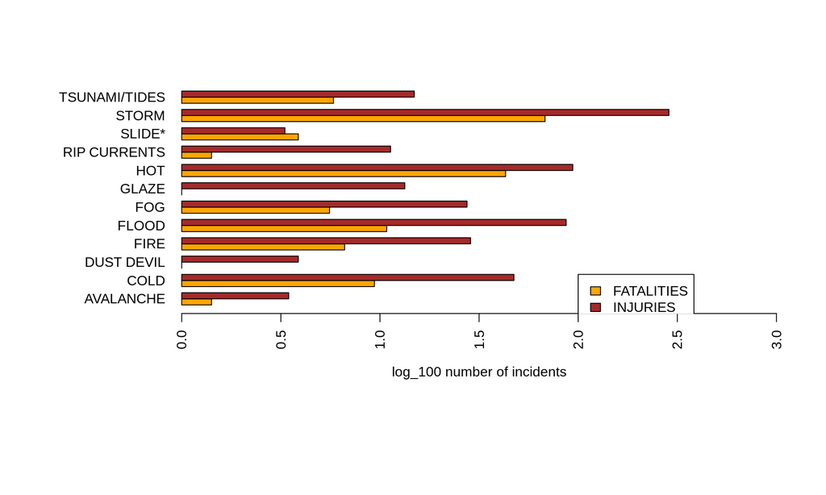

```r
#subset(x=DATA, DATA$FATALITIES>10 ||DATA$INJURIES>10 , select=c(FATALITIES,INJURIES, #EVTYPE_modified))
#table(subset(x=DATA, DATA$FATALITIES>10 |DATA$INJURIES>10 , select=c(FATALITIES,INJURIES, EVTYPE_modified)))

SUBDATA<- subset(x=DATA, DATA$FATALITIES>10|DATA$INJURIES>10 , select=c(FATALITIES,INJURIES, EVTYPE_modified))
total<-aggregate(SUBDATA[,1:2 ], list(SUBDATA$EVTYPE_modified), FUN=function(x){sum(x,na.rm=TRUE)})
colnames(total)<-c("EVTYPE","FATALITIES","INJURIES")

par(mar = c(10,10,4,2) + 1, par(las=2))
barplot(log(as.matrix(t(total[,2:3] +1)), base = 100), col=c("orange", "brown"),
        xlab= "log_100 number of incidents", axisnames = T ,xlim=c(0,3),
        names.arg  = as.vector(total$EVTYPE),beside = TRUE, horiz = T
)

legend(x=2,y=6, legend = colnames(total)[2:3],
       fill = c("orange", "brown"), box.lty = 1, cex = 1)
```

To filter the dmage impact we would consider a damage with public impact if its cost are above 10 million dollars

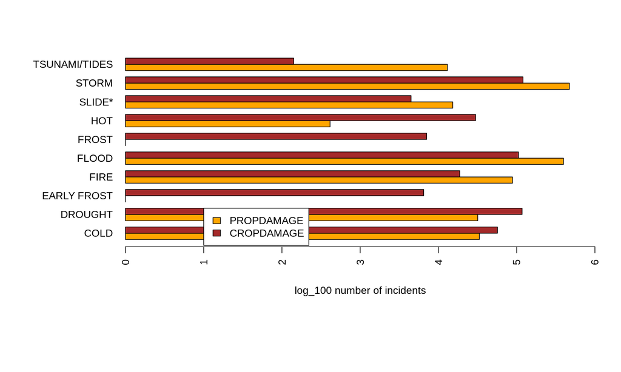

```r
SUBDATA<- subset(x=DATA, DATA$PROPDAMAGE>10^7|DATA$CROPDAMAGE>10^7 , select=c(PROPDAMAGE,CROPDAMAGE, EVTYPE_modified))
total<-aggregate(SUBDATA[,1:2 ], list(SUBDATA$EVTYPE_modified), FUN=function(x){sum(x,na.rm=TRUE)})
colnames(total)<-c("EVTYPE","PROPDAMAGE","CROPDAMAGE")

#pie(total$PROPDAMAGE, cex=1, labels = total$EVTYPE)
#pie(total$CROPDAMAGE, cex=1, labels = total$EVTYPE)
par(mar = c(10,10,4,2) + 0.1, par(las=2))
barplot(log(as.matrix(t(total[,2:3] +1)), base = 100), col=c("orange", "brown"),
        xlab= "log_100 number of incidents", axisnames = T , xlim=c(0,6),
        names.arg  = as.vector(total$EVTYPE),beside = TRUE, horiz = T
        )
legend(x=1,y=6, legend = colnames(total)[2:3],
       fill = c("orange", "brown"), box.lty = 1, cex = 1)
```

# Conclusions

On one hand, we observe that the most harmful event for public health is `STORM` and `HOT` weather in terms of fatalities and injuries. On the other hand, `FLOOD` and `STORM` create the most property and crop damages.